# Final_Project_052520

## DSC-550 Final Project

### Original Case Study - Youtube Trending Data.

**Narrative** With the COVID-19 pandemic, people around the U.S. have been forced to stay at home. In my case, I have many things to occupy myself with: Work (from home), school, family (just because they are away doesn't mean they get to go away) and, time permitting, the occasional on-line gathering with friends to play a session of Dungeons and Dragons. But what about other people?

**Step 1 - Importing the Data and Data Preparation.**

```python
# Import libraries
import pandas as pd
import numpy as np
```

Link: https://www.kaggle.com/datasnaek/youtube-new For this Case Study, we are targeting the United States, thus we will be using the following files:

- USvideos.csv
- US_category_id.json

```python
#Step 1:  Load data into a dataframe
data = pd.read_csv("USvideos.csv")

# Step 2:  check the dimension of the table
print('Dataframe size: ', data.shape)
```

```
Dataframe size:  (40949, 16)
```

```python
#Step 3:  Look at the data
data.head(5)
```

|  | video_id | trending_date | title | channel_title | category_id | publish_time | tags | views | likes | dislikes | comment_count | thumbnail_link | comments_disabled | ratings_disabled | video_error_or_removed | description |
| --- | --- | --- | --- | --- | --- | --- | --- | --- | --- | --- | --- | --- | --- | --- | --- | --- |
| 0 | 2kyS6SvSYSE | 17.14.11 | WE WANT TO TALK ABOUT OUR MARRIAGE | CaseyNeistat | 22 | 2017-11-13T17:13:01.000Z | SHANtell martin | 748374 | 57527 | 2966 | 15954 | https://i.ytimg.com/vi/2kyS6SvSYSE/default.jpg | False | False | False | SHANTELL'S CHANNEL - https://www.youtube.com/s... |
| 1 | 1ZAPwfrtAFY | 17.14.11 | The Trump Presidency: Last Week Tonight with J... | LastWeekTonight | 24 | 2017-11-13T07:30:00.000Z | last week tonight trump presidency\|"last week ... | 2418783 | 97185 | 6146 | 12703 | https://i.ytimg.com/vi/1ZAPwfrtAFY/default.jpg | False | False | False | One year after the presidential election, John... |
| 2 | 5qpjK5DgCt4 | 17.14.11 | Racist Superman \| Rudy Mancuso, King Bach & Le... | Rudy Mancuso | 23 | 2017-11-12T19:05:24.000Z | racist superman\|"rudy"\|"mancuso"\|"king"\|"bach"... | 3191434 | 146033 | 5339 | 8181 | https://i.ytimg.com/vi/5qpjK5DgCt4/default.jpg | False | False | False | WATCH MY PREVIOUS VIDEO ▶ \n\nSUBSCRIBE ► http... |
| 3 | puqaWrEC7tY | 17.14.11 | Nickelback Lyrics: Real or Fake? | Good Mythical Morning | 24 | 2017-11-13T11:00:04.000Z | rhett and link\|"gmm"\|"good mythical morning"\|"... | 343168 | 10172 | 666 | 2146 | https://i.ytimg.com/vi/puqaWrEC7tY/default.jpg | False | False | False | Today we find out if Link is a Nickelback amat... |
| 4 | d380meD0W0M | 17.14.11 | I Dare You: GOING BALD!? | nigahiga | 24 | 2017-11-12T18:01:41.000Z | ryan\|"higa"\|"higatv"\|"nigahiga"\|"i dare you"\|"... | 2095731 | 132235 | 1989 | 17518 | https://i.ytimg.com/vi/d380meD0W0M/default.jpg | False | False | False | I know it's been a while since we did this sho... |

```python
# Looking at the the data types.
data.dtypes
```

```
video_id                  object
trending_date             object
title                     object
channel_title             object
category_id                int64
publish_time              object
tags                      object
views                      int64
likes                      int64
dislikes                   int64
comment_count              int64
thumbnail_link            object
comments_disabled           bool
ratings_disabled            bool
video_error_or_removed      bool
description               object
dtype: object
```

An initial inspection of the dataframe reveals the following details:

- trending_date and publish_time are not in date-time format.
- category_id is only a number. The category labels can be found in the US_category_id.json file.

We need to import this data and merge it together.

```python
# Load json library
import json

# Opening the file and data into the data_json variable.
with open('US_category_id.json') as f:
    data_json = json.load(f)

# Looking at the resulting JSON file.
data_json
```

```
{'kind': 'youtube#videoCategoryListResponse',
 'etag': '"m2yskBQFythfE4irbTIeOgYYfBU/S730Ilt-Fi-emsQJvJAAShlR6hM"',
 'items': [{'kind': 'youtube#videoCategory',
   'etag': '"m2yskBQFythfE4irbTIeOgYYfBU/Xy1mB4_yLrHy_BmKmPBggty2mZQ"',
   'id': '1',
   'snippet': {'channelId': 'UCBR8-60-B28hp2BmDPdntcQ',
    'title': 'Film & Animation',
    'assignable': True}},
  {'kind': 'youtube#videoCategory',
   'etag': '"m2yskBQFythfE4irbTIeOgYYfBU/UZ1oLIIz2dxIhO45ZTFR3a3NyTA"',
   'id': '2',
   'snippet': {'channelId': 'UCBR8-60-B28hp2BmDPdntcQ',
    'title': 'Autos & Vehicles',
    'assignable': True}},
  {'kind': 'youtube#videoCategory',
   'etag': '"m2yskBQFythfE4irbTIeOgYYfBU/nqRIq97-xe5XRZTxbknKFVe5Lmg"',
   'id': '10',
   'snippet': {'channelId': 'UCBR8-60-B28hp2BmDPdntcQ',
    'title': 'Music',
    'assignable': True}},
  {'kind': 'youtube#videoCategory',
   'etag': '"m2yskBQFythfE4irbTIeOgYYfBU/HwXKamM1Q20q9BN-oBJavSGkfDI"',
   'id': '15',
   'snippet': {'channelId': 'UCBR8-60-B28hp2BmDPdntcQ',
    'title': 'Pets & Animals',
    'assignable': True}},
  {'kind': 'youtube#videoCategory',
   'etag': '"m2yskBQFythfE4irbTIeOgYYfBU/9GQMSRjrZdHeb1OEM1XVQ9zbGec"',
   'id': '17',
   'snippet': {'channelId': 'UCBR8-60-B28hp2BmDPdntcQ',
    'title': 'Sports',
    'assignable': True}},
  {'kind': 'youtube#videoCategory',
   'etag': '"m2yskBQFythfE4irbTIeOgYYfBU/FJwVpGCVZ1yiJrqZbpqe68Sy_OE"',
   'id': '18',
   'snippet': {'channelId': 'UCBR8-60-B28hp2BmDPdntcQ',
    'title': 'Short Movies',
    'assignable': False}},
  {'kind': 'youtube#videoCategory',
   'etag': '"m2yskBQFythfE4irbTIeOgYYfBU/M-3iD9dwK7YJCafRf_DkLN8CouA"',
```

[output cut: 139 more lines]

```
   'snippet': {'channelId': 'UCBR8-60-B28hp2BmDPdntcQ',
    'title': 'Shorts',
    'assignable': False}},
  {'kind': 'youtube#videoCategory',
   'etag': '"m2yskBQFythfE4irbTIeOgYYfBU/0n9MJVCDLpA8q7aiGVrFsuFsd0A"',
   'id': '43',
   'snippet': {'channelId': 'UCBR8-60-B28hp2BmDPdntcQ',
    'title': 'Shows',
    'assignable': False}},
  {'kind': 'youtube#videoCategory',
   'etag': '"m2yskBQFythfE4irbTIeOgYYfBU/x5NxSf5fz8hn4loSN4rvhwzD_pY"',
   'id': '44',
   'snippet': {'channelId': 'UCBR8-60-B28hp2BmDPdntcQ',
    'title': 'Trailers',
    'assignable': False}}]}
```

```python
# Getting the category data
cat_data = data_json['items']

# Dictionary comprehension to pair the category id with their corresponding name/title
cat_dict = { int(item['id']) : item['snippet']['title'] for item in cat_data}

# Convert the dictionary into a dataframe
cat_df = pd.DataFrame(list(cat_dict.items()), columns=['category_id','category'])
```

```python
# Use one-hot encoding on categories.
dum_df = pd.get_dummies(cat_df, columns=["category"], prefix=["Type_is"] )
cat_df = pd.merge(cat_df,dum_df, on='category_id', how='left')
cat_df.describe()
```

|  | category_id | Type_is_Action/Adventure | Type_is_Anime/Animation | Type_is_Autos & Vehicles | Type_is_Classics | Type_is_Comedy | Type_is_Documentary | Type_is_Drama | Type_is_Education | Type_is_Entertainment | ... | Type_is_Sci-Fi/Fantasy | Type_is_Science & Technology | Type_is_Short Movies | Type_is_Shorts | Type_is_Shows | Type_is_Sports | Type_is_Thriller | Type_is_Trailers | Type_is_Travel & Events | Type_is_Videoblogging |
| --- | --- | --- | --- | --- | --- | --- | --- | --- | --- | --- | --- | --- | --- | --- | --- | --- | --- | --- | --- | --- | --- |
| count | 32.000000 | 32.000000 | 32.000000 | 32.000000 | 32.000000 | 32.000000 | 32.000000 | 32.000000 | 32.000000 | 32.000000 | ... | 32.000000 | 32.000000 | 32.000000 | 32.000000 | 32.000000 | 32.000000 | 32.000000 | 32.000000 | 32.000000 | 32.000000 |
| mean | 27.562500 | 0.031250 | 0.031250 | 0.031250 | 0.031250 | 0.062500 | 0.031250 | 0.031250 | 0.031250 | 0.031250 | ... | 0.031250 | 0.031250 | 0.031250 | 0.031250 | 0.031250 | 0.031250 | 0.031250 | 0.031250 | 0.031250 | 0.031250 |
| std | 11.207536 | 0.176777 | 0.176777 | 0.176777 | 0.176777 | 0.245935 | 0.176777 | 0.176777 | 0.176777 | 0.176777 | ... | 0.176777 | 0.176777 | 0.176777 | 0.176777 | 0.176777 | 0.176777 | 0.176777 | 0.176777 | 0.176777 | 0.176777 |
| min | 1.000000 | 0.000000 | 0.000000 | 0.000000 | 0.000000 | 0.000000 | 0.000000 | 0.000000 | 0.000000 | 0.000000 | ... | 0.000000 | 0.000000 | 0.000000 | 0.000000 | 0.000000 | 0.000000 | 0.000000 | 0.000000 | 0.000000 | 0.000000 |
| 25% | 20.750000 | 0.000000 | 0.000000 | 0.000000 | 0.000000 | 0.000000 | 0.000000 | 0.000000 | 0.000000 | 0.000000 | ... | 0.000000 | 0.000000 | 0.000000 | 0.000000 | 0.000000 | 0.000000 | 0.000000 | 0.000000 | 0.000000 | 0.000000 |
| 50% | 28.500000 | 0.000000 | 0.000000 | 0.000000 | 0.000000 | 0.000000 | 0.000000 | 0.000000 | 0.000000 | 0.000000 | ... | 0.000000 | 0.000000 | 0.000000 | 0.000000 | 0.000000 | 0.000000 | 0.000000 | 0.000000 | 0.000000 | 0.000000 |
| 75% | 36.250000 | 0.000000 | 0.000000 | 0.000000 | 0.000000 | 0.000000 | 0.000000 | 0.000000 | 0.000000 | 0.000000 | ... | 0.000000 | 0.000000 | 0.000000 | 0.000000 | 0.000000 | 0.000000 | 0.000000 | 0.000000 | 0.000000 | 0.000000 |
| max | 44.000000 | 1.000000 | 1.000000 | 1.000000 | 1.000000 | 1.000000 | 1.000000 | 1.000000 | 1.000000 | 1.000000 | ... | 1.000000 | 1.000000 | 1.000000 | 1.000000 | 1.000000 | 1.000000 | 1.000000 | 1.000000 | 1.000000 | 1.000000 |

8 rows × 32 columns

```python
# Merging data with category data.
data_r2 = pd.merge(data, cat_df, on='category_id', how='left')
```

Next, converting the trending_date and publish_time to datetime. Starting with trending_date, we notice that the format is an object that represents YY.DD.MM so we'll need to perform a couple of operations on this to get the datetime. With publish_time, we can split the time and date respectively.

```python
# Convert from object to string.
data_r2['trending_date'] = data_r2['trending_date'].astype(str)

# Split the Year, Month and Date into separate columns,
data_r2[['Year','Date','Month']] = data_r2.trending_date.str.split(".",expand=True)

# Convert Year, Month and Date into an integer
data_r2['Year'] = data_r2['Year'].astype(int)
data_r2['Date'] = data_r2['Date'].astype(int)
data_r2['Month'] = data_r2['Month'].astype(int)

# Add 2000 to the year
data_r2['Year'] = 2000 + data_r2['Year']

# Convert the the int year, month and date into a string.
data_r2['trending_date_int']= (data_r2['Year']* 10000 + data_r2['Month']* 100 +data_r2['Date'])

# Convert the the int year, month and date into a string and apply the the pandas datetime transformation
data_r2['trending_date_r'] = pd.to_datetime((data_r2['Year']* 10000 + data_r2['Month']* 100 +data_r2['Date']).astype(str),format='%Y%m%d')

# Split date and time from
data_r2[['publish_date','publish_time_r']] = data_r2.publish_time.str.split("T",expand=True)

# Convert the publish_date into datetime format.
data_r2['publish_date_r'] = pd.to_datetime((data_r2['publish_date']).astype(str),format='%Y-%m-%d')
```

Next - Create some derived variables that help us to gauge the overall sentiment of these videos as well as how fast they are trending - We do that as follows:

```python
# Function that subtracts the number of likes against dislikes, if the value is positive then returns a 1, else returns a 0.
def video_sentiment(row):
    result = row['likes'] - row['dislikes']
    if result > 0:
        value = 1
    else:
        value = 0
    return value
```

```python
# Apply the function to return the positive sentiment.
data_r2['isPositive'] = data_r2.apply(video_sentiment, axis=1)

# Get the number of days between publish date and trending date:
data_r2['days_toTrend'] = (data_r2['trending_date_r'] - data_r2['publish_date_r']) / np.timedelta64(1, 'D')
```

Here we take a look at the resulting dataframe and it's descriptive statistics:

```python
# One final look at the dtypes.
data_r2.dtypes
```

```
video_id                                 object
trending_date                            object
title                                    object
channel_title                            object
category_id                               int64
publish_time                             object
tags                                     object
views                                     int64
likes                                     int64
dislikes                                  int64
comment_count                             int64
thumbnail_link                           object
comments_disabled                          bool
ratings_disabled                           bool
video_error_or_removed                     bool
description                              object
category                                 object
Type_is_Action/Adventure                  uint8
Type_is_Anime/Animation                   uint8
Type_is_Autos & Vehicles                  uint8
Type_is_Classics                          uint8
Type_is_Comedy                            uint8
Type_is_Documentary                       uint8
Type_is_Drama                             uint8
Type_is_Education                         uint8
Type_is_Entertainment                     uint8
Type_is_Family                            uint8
Type_is_Film & Animation                  uint8
Type_is_Foreign                           uint8
Type_is_Gaming                            uint8
Type_is_Horror                            uint8
Type_is_Howto & Style                     uint8
Type_is_Movies                            uint8
Type_is_Music                             uint8
Type_is_News & Politics                   uint8
Type_is_Nonprofits & Activism             uint8
Type_is_People & Blogs                    uint8
Type_is_Pets & Animals                    uint8
Type_is_Sci-Fi/Fantasy                    uint8
Type_is_Science & Technology              uint8
Type_is_Short Movies                      uint8
Type_is_Shorts                            uint8
Type_is_Shows                             uint8
Type_is_Sports                            uint8
Type_is_Thriller                          uint8
Type_is_Trailers                          uint8
Type_is_Travel & Events                   uint8
Type_is_Videoblogging                     uint8
Year                                      int64
Date                                      int64
Month                                     int64
trending_date_int                         int64
trending_date_r                  datetime64[ns]
publish_date                             object
publish_time_r                           object
publish_date_r                   datetime64[ns]
isPositive                                int64
days_toTrend                            float64
dtype: object
```

```python
print('Dataframe size: ', data_r2.shape)
```

```
Dataframe size:  (40949, 58)
```

```python
# Printing the head of the dataframe.
data_r2.head()
```

|  | video_id | trending_date | title | channel_title | category_id | publish_time | tags | views | likes | dislikes | ... | Year | Date | Month | trending_date_int | trending_date_r | publish_date | publish_time_r | publish_date_r | isPositive | days_toTrend |
| --- | --- | --- | --- | --- | --- | --- | --- | --- | --- | --- | --- | --- | --- | --- | --- | --- | --- | --- | --- | --- | --- |
| 0 | 2kyS6SvSYSE | 17.14.11 | WE WANT TO TALK ABOUT OUR MARRIAGE | CaseyNeistat | 22 | 2017-11-13T17:13:01.000Z | SHANtell martin | 748374 | 57527 | 2966 | ... | 2017 | 14 | 11 | 20171114 | 2017-11-14 | 2017-11-13 | 17:13:01.000Z | 2017-11-13 | 1 | 1.0 |
| 1 | 1ZAPwfrtAFY | 17.14.11 | The Trump Presidency: Last Week Tonight with J... | LastWeekTonight | 24 | 2017-11-13T07:30:00.000Z | last week tonight trump presidency\|"last week ... | 2418783 | 97185 | 6146 | ... | 2017 | 14 | 11 | 20171114 | 2017-11-14 | 2017-11-13 | 07:30:00.000Z | 2017-11-13 | 1 | 1.0 |
| 2 | 5qpjK5DgCt4 | 17.14.11 | Racist Superman \| Rudy Mancuso, King Bach & Le... | Rudy Mancuso | 23 | 2017-11-12T19:05:24.000Z | racist superman\|"rudy"\|"mancuso"\|"king"\|"bach"... | 3191434 | 146033 | 5339 | ... | 2017 | 14 | 11 | 20171114 | 2017-11-14 | 2017-11-12 | 19:05:24.000Z | 2017-11-12 | 1 | 2.0 |
| 3 | puqaWrEC7tY | 17.14.11 | Nickelback Lyrics: Real or Fake? | Good Mythical Morning | 24 | 2017-11-13T11:00:04.000Z | rhett and link\|"gmm"\|"good mythical morning"\|"... | 343168 | 10172 | 666 | ... | 2017 | 14 | 11 | 20171114 | 2017-11-14 | 2017-11-13 | 11:00:04.000Z | 2017-11-13 | 1 | 1.0 |
| 4 | d380meD0W0M | 17.14.11 | I Dare You: GOING BALD!? | nigahiga | 24 | 2017-11-12T18:01:41.000Z | ryan\|"higa"\|"higatv"\|"nigahiga"\|"i dare you"\|"... | 2095731 | 132235 | 1989 | ... | 2017 | 14 | 11 | 20171114 | 2017-11-14 | 2017-11-12 | 18:01:41.000Z | 2017-11-12 | 1 | 2.0 |

5 rows × 58 columns

```python
print("Describe Data: ")
data_r2.describe()
```

```
Describe Data:
```

|  | category_id | views | likes | dislikes | comment_count | Type_is_Action/Adventure | Type_is_Anime/Animation | Type_is_Autos & Vehicles | Type_is_Classics | Type_is_Comedy | ... | Type_is_Thriller | Type_is_Trailers | Type_is_Travel & Events | Type_is_Videoblogging | Year | Date | Month | trending_date_int | isPositive | days_toTrend |
| --- | --- | --- | --- | --- | --- | --- | --- | --- | --- | --- | --- | --- | --- | --- | --- | --- | --- | --- | --- | --- | --- |
| count | 40949.000000 | 4.094900e+04 | 4.094900e+04 | 4.094900e+04 | 4.094900e+04 | 40949.0 | 40949.0 | 40949.000000 | 40949.0 | 40949.000000 | ... | 40949.0 | 40949.0 | 40949.000000 | 40949.0 | 40949.000000 | 40949.000000 | 40949.000000 | 4.094900e+04 | 40949.000000 | 40949.000000 |
| mean | 19.972429 | 2.360785e+06 | 7.426670e+04 | 3.711401e+03 | 8.446804e+03 | 0.0 | 0.0 | 0.009378 | 0.0 | 0.084422 | ... | 0.0 | 0.0 | 0.009817 | 0.0 | 2017.765562 | 15.857457 | 5.232899 | 2.017819e+07 | 0.981514 | 16.810423 |
| std | 7.568327 | 7.394114e+06 | 2.288853e+05 | 2.902971e+04 | 3.743049e+04 | 0.0 | 0.0 | 0.096384 | 0.0 | 0.278023 | ... | 0.0 | 0.0 | 0.098595 | 0.0 | 0.423652 | 8.849585 | 3.825291 | 3.882975e+03 | 0.134704 | 146.014303 |
| min | 1.000000 | 5.490000e+02 | 0.000000e+00 | 0.000000e+00 | 0.000000e+00 | 0.0 | 0.0 | 0.000000 | 0.0 | 0.000000 | ... | 0.0 | 0.0 | 0.000000 | 0.0 | 2017.000000 | 1.000000 | 1.000000 | 2.017111e+07 | 0.000000 | 0.000000 |
| 25% | 17.000000 | 2.423290e+05 | 5.424000e+03 | 2.020000e+02 | 6.140000e+02 | 0.0 | 0.0 | 0.000000 | 0.0 | 0.000000 | ... | 0.0 | 0.0 | 0.000000 | 0.0 | 2018.000000 | 8.000000 | 2.000000 | 2.018010e+07 | 1.000000 | 3.000000 |
| 50% | 24.000000 | 6.818610e+05 | 1.809100e+04 | 6.310000e+02 | 1.856000e+03 | 0.0 | 0.0 | 0.000000 | 0.0 | 0.000000 | ... | 0.0 | 0.0 | 0.000000 | 0.0 | 2018.000000 | 16.000000 | 4.000000 | 2.018023e+07 | 1.000000 | 5.000000 |
| 75% | 25.000000 | 1.823157e+06 | 5.541700e+04 | 1.938000e+03 | 5.755000e+03 | 0.0 | 0.0 | 0.000000 | 0.0 | 0.000000 | ... | 0.0 | 0.0 | 0.000000 | 0.0 | 2018.000000 | 23.000000 | 6.000000 | 2.018042e+07 | 1.000000 | 9.000000 |
| max | 43.000000 | 2.252119e+08 | 5.613827e+06 | 1.674420e+06 | 1.361580e+06 | 0.0 | 0.0 | 1.000000 | 0.0 | 1.000000 | ... | 0.0 | 0.0 | 1.000000 | 0.0 | 2018.000000 | 31.000000 | 12.000000 | 2.018061e+07 | 1.000000 | 4215.000000 |

8 rows × 42 columns

```python
print("Summarized Data")
data_r2.describe(include=['O'])
```

```
Summarized Data
```

|  | video_id | trending_date | title | channel_title | publish_time | tags | thumbnail_link | description | category | publish_date | publish_time_r |
| --- | --- | --- | --- | --- | --- | --- | --- | --- | --- | --- | --- |
| count | 40949 | 40949 | 40949 | 40949 | 40949 | 40949 | 40949 | 40379 | 40949 | 40949 | 40949 |
| unique | 6351 | 205 | 6455 | 2207 | 6269 | 6055 | 6352 | 6901 | 16 | 313 | 4478 |
| top | j4KvrAUjn6c | 17.08.12 | WE MADE OUR MOM CRY...HER DREAM CAME TRUE! | ESPN | 2018-05-18T14:00:04.000Z | [none] | https://i.ytimg.com/vi/j4KvrAUjn6c/default.jpg | ► Listen LIVE: http://power1051fm.com/\n► Face... | Entertainment | 2017-12-22 | 14:00:03.000Z |
| freq | 30 | 200 | 30 | 203 | 50 | 1535 | 30 | 58 | 9964 | 452 | 250 |

## Visualizations.

```python
# Import matplotlib and seaborn
import matplotlib.pyplot as plt
import seaborn as sn
```

**Histograms**

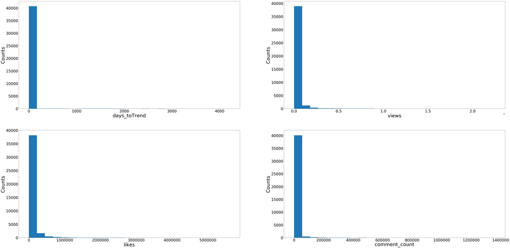

```python
# set up the figure size
plt.rcParams['figure.figsize'] = (80, 40)
# make subplots
fig, axes = plt.subplots(nrows = 2, ncols = 2)
# Specify the features of interest
num_features = ['days_toTrend', 'views', 'likes', 'comment_count']
xaxes = num_features
yaxes = ['Counts', 'Counts', 'Counts', 'Counts']
# draw histograms
axes = axes.ravel()
for idx, ax in enumerate(axes):
    ax.hist(data_r2[num_features[idx]].dropna(), bins=25)
    ax.set_xlabel(xaxes[idx], fontsize=45)
    ax.set_ylabel(yaxes[idx], fontsize=45)
    ax.tick_params(axis='both', labelsize=35)
```

**Bar Charts**

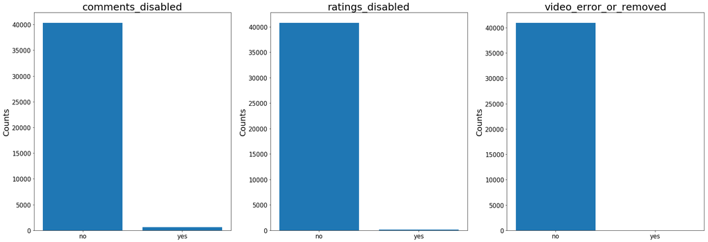

```python
# Barcharts: set up the figure size
plt.rcParams['figure.figsize'] = (30, 10)

# Make subplots
fig, axes = plt.subplots(nrows = 1, ncols = 3)

# Feed the comments disabled
x_comments = data_r2.replace({'comments_disabled': {True: 'yes', False: 'no'}}).groupby('comments_disabled').size().reset_index(name='Counts')['comments_disabled']
y_comments = data_r2.replace({'comments_disabled': {True: 'yes', False: 'no'}}).groupby('comments_disabled').size().reset_index(name='Counts')['Counts']
# make the bar plot
axes[0].bar(x_comments, y_comments)
axes[0].set_title('comments_disabled', fontsize=25)
axes[0].set_ylabel('Counts', fontsize=20)
axes[0].tick_params(axis='both', labelsize=15)

# Feed the ratings disabled
x_comments = data_r2.replace({'ratings_disabled': {True: 'yes', False: 'no'}}).groupby('ratings_disabled').size().reset_index(name='Counts')['ratings_disabled']
y_comments = data_r2.replace({'ratings_disabled': {True: 'yes', False: 'no'}}).groupby('ratings_disabled').size().reset_index(name='Counts')['Counts']
# make the bar plot
axes[1].bar(x_comments, y_comments)
axes[1].set_title('ratings_disabled', fontsize=25)
axes[1].set_ylabel('Counts', fontsize=20)
axes[1].tick_params(axis='both', labelsize=15)

# Feed the the video error/removed data
x_ratings = data_r2.replace({'video_error_or_removed': {True: 'yes', False: 'no'}}).groupby('video_error_or_removed').size().reset_index(name='Counts')['video_error_or_removed']
y_ratings = data_r2.replace({'video_error_or_removed': {True: 'yes', False: 'no'}}).groupby('video_error_or_removed').size().reset_index(name='Counts')['Counts']
# make the bar plot
axes[2].bar(x_ratings, y_ratings)
axes[2].set_title('video_error_or_removed', fontsize=25)
axes[2].set_ylabel('Counts', fontsize=20)
axes[2].tick_params(axis='both', labelsize=15)
```

The three charts above compare the total count of videos that had their comments and ratings disabled as well if any of the videos have been removed or no longer exist because of an error. As we can see, the number of videos that had these options disabled is very small while none of the videos on this list have been removed.

Next we take a look at the the total count of videos by category and then by count order.

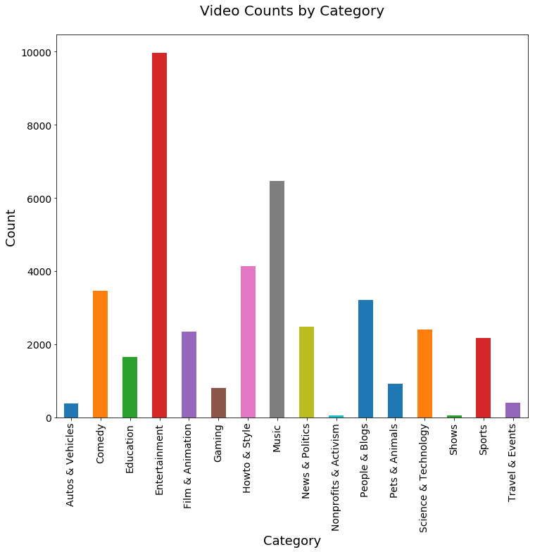

```python
ax = data_r2['category'].value_counts().sort_index().plot(kind='bar', fontsize=14, figsize=(12,10))
ax.set_title('Video Counts by Category\n', fontsize=20)
ax.set_xlabel('Category', fontsize=18)
ax.set_ylabel('Count', fontsize=18);
plt.show()
```

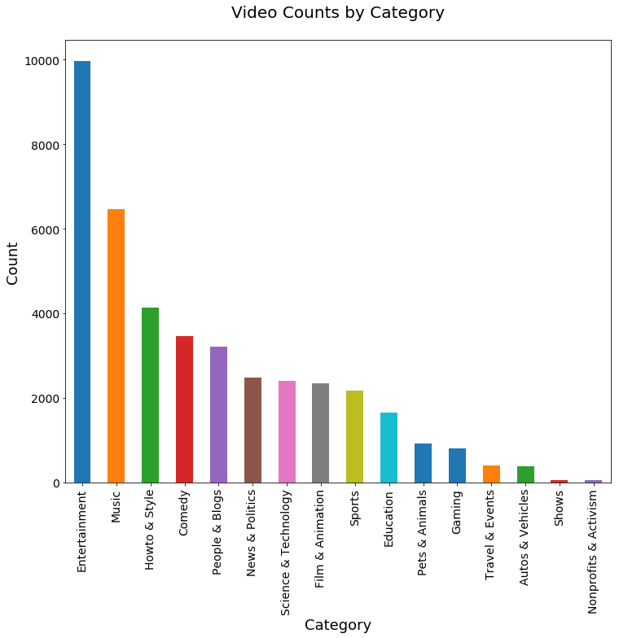

```python
ax = data_r2['category'].value_counts().plot(kind='bar', fontsize=14, figsize=(12,10))
ax.set_title('Video Counts by Category\n', fontsize=20)
ax.set_xlabel('Category', fontsize=18)
ax.set_ylabel('Count', fontsize=18);
plt.show()
```

This one is to look at the top ten video channels based on how many videos they've posted.

```python
# Create the channel video counts.
channel_video_counts = data_r2['channel_title'].value_counts().sort_index().reset_index()
channel_video_counts = channel_video_counts.sort_values("channel_title", ascending = False).head(10)
channel_video_counts.set_index("index", inplace = True)
channel_video_counts.rename({'channel_title': 'counts'}, axis=1, inplace=True)
channel_video_counts
```

| index | counts |
| --- | --- |
| ESPN | 203 |
| The Tonight Show Starring Jimmy Fallon | 197 |
| Vox | 193 |
| Netflix | 193 |
| TheEllenShow | 193 |
| The Late Show with Stephen Colbert | 187 |
| Jimmy Kimmel Live | 186 |
| Late Night with Seth Meyers | 183 |
| Screen Junkies | 182 |
| NBA | 181 |

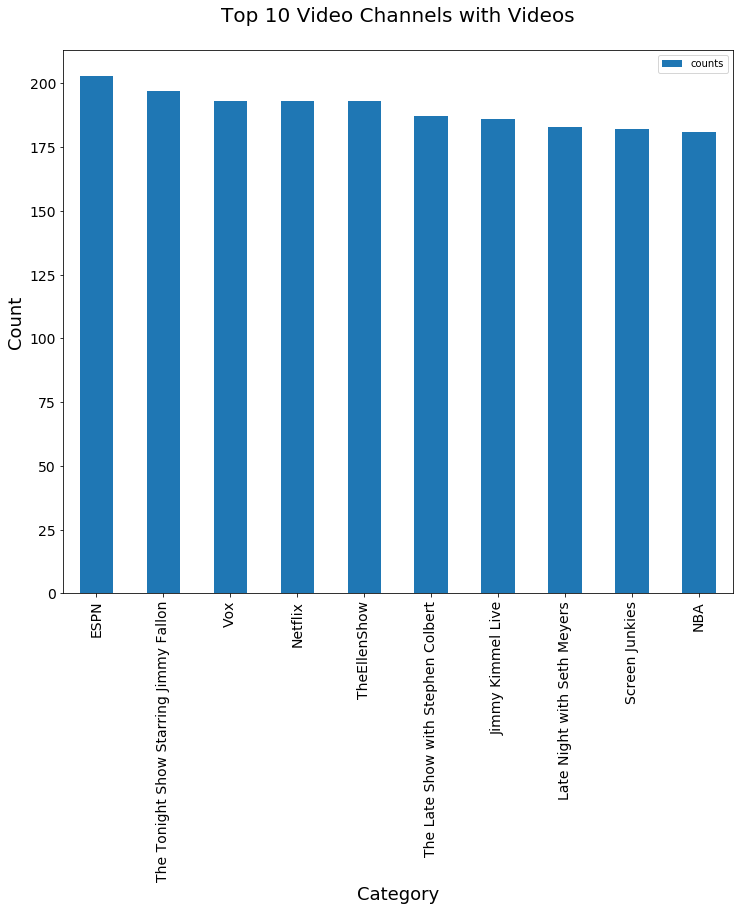

```python
ax = channel_video_counts.plot(kind='bar', fontsize=14, figsize=(12,10))
ax.set_title('Top 10 Video Channels with Videos\n', fontsize=20)
ax.set_xlabel('Category', fontsize=18)
ax.set_ylabel('Count', fontsize=18);
plt.show()
```

**Pearson Ranking**

```python
feature_names = ['views', 'likes', 'dislikes','comment_count','days_toTrend']
target_name = 'Type_is_Entertainment'
X = data_r2[feature_names]
y = data_r2[target_name]
```

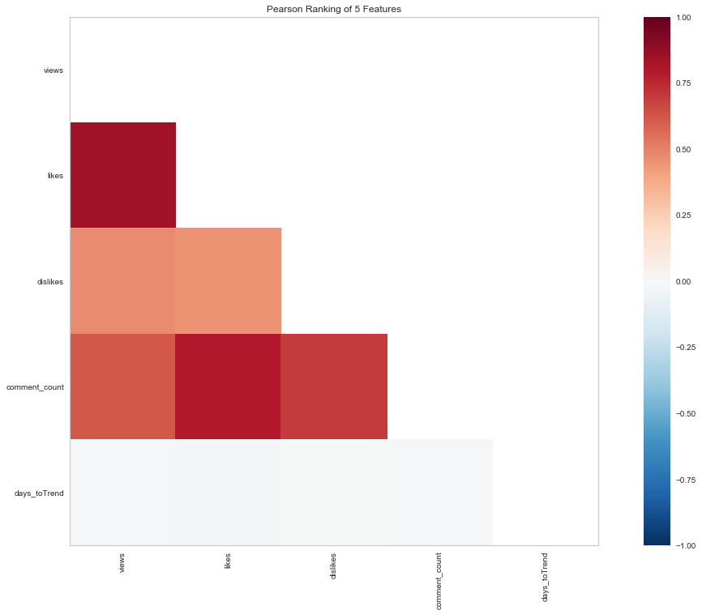

```python
# Import Rank2D
from yellowbrick.features import Rank2D

# Instantiate the visualizer with the Pearson ranking algorithm
plt.rcParams['figure.figsize'] = (20, 12)
visualizer = Rank2D(features=feature_names, algorithm='pearson')
visualizer.fit(X, y)
visualizer.transform(X)
visualizer.poof()
```

The Pearson ranking reveals that there is a positive correlation between the following variables (meaning as one increases so those does the other):

- likes and views.
- likes and comment counts.
- views and dislikes.

**Parallel Coordinates**

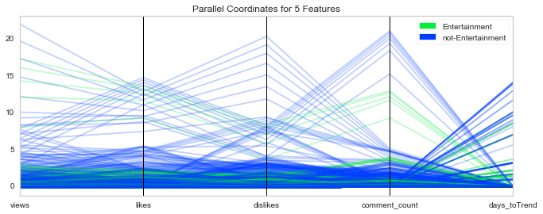

```python
# Import parallel coordinates.
from yellowbrick.features import ParallelCoordinates
plt.rcParams['figure.figsize'] = (60, 40)
plt.rcParams['font.size'] = 30

# setup the color for yellowbrick visualizer
from yellowbrick.style import set_palette
set_palette('sns_bright')

features = feature_names
classes = ['not-Entertainment', 'Entertainment']
# Instantiate the visualizer
visualizer = visualizer = ParallelCoordinates(
    classes=classes, features=features,
    normalize='standard', sample=0.1, size = (800,300)
)
visualizer.fit(X, y)
visualizer.transform(X)
visualizer.poof()
```

**Stacked Bar-Charts** Here, we compare the number of likes vs dislikes per Category.

```python
# Sub-Select the data.
data_final_s = data_r2[['category', 'likes', 'dislikes']]
# Group by Category and set this as the index
gk = data_final_s.groupby('category', as_index=False).sum()
gk.set_index('category', inplace=True)
# Resulting Data-frame.
gk
```

| category | likes | dislikes |
| --- | --- | --- |
| Autos & Vehicles | 4245656 | 243010 |
| Comedy | 216346746 | 7230391 |
| Education | 49257772 | 1351972 |
| Entertainment | 530516491 | 42987663 |
| Film & Animation | 165997476 | 6075148 |
| Gaming | 69038284 | 9184466 |
| Howto & Style | 162880075 | 5473899 |
| Music | 1416838584 | 51179008 |
| News & Politics | 18151033 | 4180049 |
| Nonprofits & Activism | 14815646 | 3310381 |
| People & Blogs | 186615999 | 10187901 |
| Pets & Animals | 19370702 | 527379 |
| Science & Technology | 82532638 | 4548402 |
| Shows | 1082639 | 24508 |
| Sports | 98621211 | 5133551 |
| Travel & Events | 4836246 | 340427 |

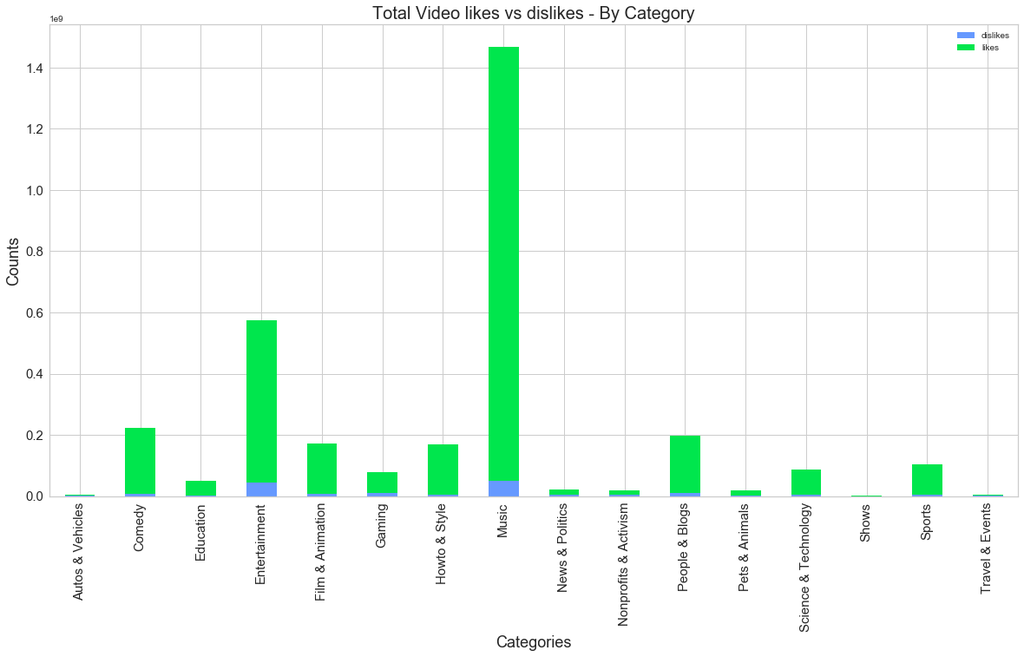

```python
# Creating the visualization.
gk.loc[:,['dislikes','likes']].plot.bar(stacked=True, figsize=(20,10),color=['#6699ff','#00e64d'], fontsize=15)
plt.title('Total Video likes vs dislikes - By Category', fontsize=20)
plt.xlabel('Categories', fontsize=18)
plt.ylabel('Counts', fontsize=18)
```

This chart provides an interesting trend - While the total count of Entertainment is higher, people tend to provide more feedback on Music related videos.

**Discovering NA/Null values**

```python
# Discover which columns/series has null values.
nan_values = data_r2.isna()
nan_columns = nan_values.any()
columns_with_nan = data_r2.columns[nan_columns].tolist()
columns_with_nan
```

```
['description']
```

The only null column that has null values is the description column. Ultimately, I made the decision to drop this column as it will not be used for this analysis.

**Log Transformations**

```python
# log-transformation
def log_transformation(data):
    return data.apply(np.log1p)
```

```python
# Apply log transformations to views, likes, dislikes and comment counts
data_r2['views_log1p'] = log_transformation(data_r2['views'])
data_r2['views_log1p'] = log_transformation(data_r2['views'])
data_r2['likes_log1p'] = log_transformation(data_r2['likes'])
data_r2['dislikes_log1p'] = log_transformation(data_r2['dislikes'])
data_r2['comment_count_log1p'] = log_transformation(data_r2['comment_count'])

# Looking at the data-frame
data_r2.describe()
```

|  | category_id | views | likes | dislikes | comment_count | Type_is_Action/Adventure | Type_is_Anime/Animation | Type_is_Autos & Vehicles | Type_is_Classics | Type_is_Comedy | ... | Year | Date | Month | trending_date_int | isPositive | days_toTrend | views_log1p | likes_log1p | dislikes_log1p | comment_count_log1p |
| --- | --- | --- | --- | --- | --- | --- | --- | --- | --- | --- | --- | --- | --- | --- | --- | --- | --- | --- | --- | --- | --- |
| count | 40949.000000 | 4.094900e+04 | 4.094900e+04 | 4.094900e+04 | 4.094900e+04 | 40949.0 | 40949.0 | 40949.000000 | 40949.0 | 40949.000000 | ... | 40949.000000 | 40949.000000 | 40949.000000 | 4.094900e+04 | 40949.000000 | 40949.000000 | 40949.000000 | 40949.000000 | 40949.000000 | 40949.000000 |
| mean | 19.972429 | 2.360785e+06 | 7.426670e+04 | 3.711401e+03 | 8.446804e+03 | 0.0 | 0.0 | 0.009378 | 0.0 | 0.084422 | ... | 2017.765562 | 15.857457 | 5.232899 | 2.017819e+07 | 0.981514 | 16.810423 | 13.337995 | 9.599392 | 6.387610 | 7.387712 |
| std | 7.568327 | 7.394114e+06 | 2.288853e+05 | 2.902971e+04 | 3.743049e+04 | 0.0 | 0.0 | 0.096384 | 0.0 | 0.278023 | ... | 0.423652 | 8.849585 | 3.825291 | 3.882975e+03 | 0.134704 | 146.014303 | 1.709989 | 2.115725 | 1.915583 | 2.057100 |
| min | 1.000000 | 5.490000e+02 | 0.000000e+00 | 0.000000e+00 | 0.000000e+00 | 0.0 | 0.0 | 0.000000 | 0.0 | 0.000000 | ... | 2017.000000 | 1.000000 | 1.000000 | 2.017111e+07 | 0.000000 | 0.000000 | 6.309918 | 0.000000 | 0.000000 | 0.000000 |
| 25% | 17.000000 | 2.423290e+05 | 5.424000e+03 | 2.020000e+02 | 6.140000e+02 | 0.0 | 0.0 | 0.000000 | 0.0 | 0.000000 | ... | 2018.000000 | 8.000000 | 2.000000 | 2.018010e+07 | 1.000000 | 3.000000 | 12.398056 | 8.598773 | 5.313206 | 6.421622 |
| 50% | 24.000000 | 6.818610e+05 | 1.809100e+04 | 6.310000e+02 | 1.856000e+03 | 0.0 | 0.0 | 0.000000 | 0.0 | 0.000000 | ... | 2018.000000 | 16.000000 | 4.000000 | 2.018023e+07 | 1.000000 | 5.000000 | 13.432583 | 9.803225 | 6.448889 | 7.526718 |
| 75% | 25.000000 | 1.823157e+06 | 5.541700e+04 | 1.938000e+03 | 5.755000e+03 | 0.0 | 0.0 | 0.000000 | 0.0 | 0.000000 | ... | 2018.000000 | 23.000000 | 6.000000 | 2.018042e+07 | 1.000000 | 9.000000 | 14.416081 | 10.922660 | 7.569928 | 8.657998 |
| max | 43.000000 | 2.252119e+08 | 5.613827e+06 | 1.674420e+06 | 1.361580e+06 | 0.0 | 0.0 | 1.000000 | 0.0 | 1.000000 | ... | 2018.000000 | 31.000000 | 12.000000 | 2.018061e+07 | 1.000000 | 4215.000000 | 19.232552 | 15.540743 | 14.330978 | 14.124157 |

8 rows × 46 columns

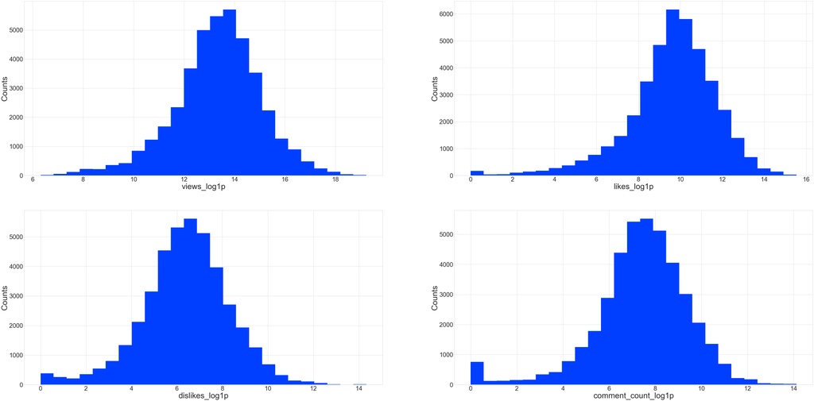

```python
# set up the figure size
plt.rcParams['figure.figsize'] = (80, 40)
# make subplots
fig, axes = plt.subplots(nrows = 2, ncols = 2)
# Specify the features of interest
num_features = ['views_log1p', 'likes_log1p', 'dislikes_log1p', 'comment_count_log1p']
xaxes = num_features
yaxes = ['Counts', 'Counts', 'Counts', 'Counts']
# draw histograms
axes = axes.ravel()
for idx, ax in enumerate(axes):
    ax.hist(data_r2[num_features[idx]].dropna(), bins=25)
    ax.set_xlabel(xaxes[idx], fontsize=45)
    ax.set_ylabel(yaxes[idx], fontsize=45)
    ax.tick_params(axis='both', labelsize=35)
```

Applying a logarithm transformation has provided a diferent view/result - These look fairly normal distributions. We do have a bit of a left tail over in likes, dislikes and comment counts - a sign of potential outliers.

**Creating a Feature for Training**

One question that arose as I was working with this dataset - What is the trending performance on each individual video? To elaborate: How can I tell if one video in particular fared better against the rest of the videos in this data set? In this case, we are going to gauge performance by comparing the total number of log views against the log views average. However, simply subtracting against the total average would not create an accurate representation, so for the purposes of this exercise we will use the average log view by category.

```python
# Sample view of the mean of log views by Category.
data_r2.groupby('category')['views_log1p'].mean()
```

```
category
Autos & Vehicles         12.730070
Comedy                   13.530411
Education                12.916893
Entertainment            13.370174
Film & Animation         13.723527
Gaming                   13.966207
Howto & Style            13.034745
Music                    14.121758
News & Politics          12.079484
Nonprofits & Activism    11.475911
People & Blogs           13.196087
Pets & Animals           12.859575
Science & Technology     13.104941
Shows                    13.332815
Sports                   13.139413
Travel & Events          12.929378
Name: views_log1p, dtype: float64
```

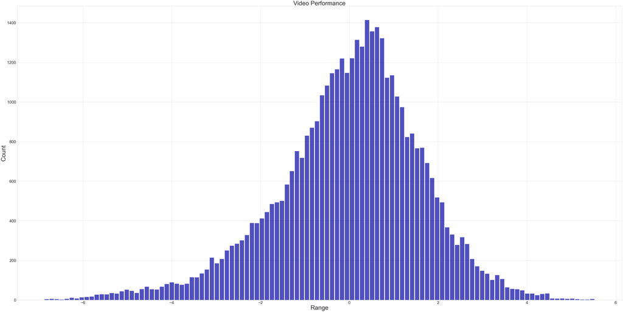

```python
# Save the resulting group by as a dataframe and set the category as the default index
log_views_bycat = data_r2.groupby('category')['views_log1p'].mean().reset_index()
log_views_bycat.rename(columns = {'views_log1p':'views_log1p_mean'}, inplace = True)

# Merge the dataframes
data_r3 = pd.merge(data_r2, log_views_bycat, on='category', how='left')

# Compare the means of log vies against the log_views
data_r3['views_log_comp'] = data_r3['views_log1p'] - data_r3['views_log1p_mean']

# Histogram to view the distribution of video performance.
n, bins, patches = plt.hist(x=data_r3['views_log_comp'], bins='auto', color='#0504aa',
                            alpha=0.7, rwidth=0.85)
plt.xlabel('Range', fontsize=45)
plt.ylabel('Count', fontsize=45)
plt.title('Video Performance', fontsize=45)
plt.tick_params(axis='both', which='major', labelsize=30)
```

```python
# Function that labels video performance by the resulting mean comparison. If the resulting value is 0 or less, it means that the views are below the mean value
# Thus labelled as a bad performer in this dataset. For any values above 0, that means the video performed better than the rest of the group.
def trend_performance(row):
    if row['views_log_comp'] < 0:
        value = 0
    else:
        value = 1
    return value
```

```python
# Apply the trend_performance function.
data_r3['better_performance'] =  data_r3.apply(trend_performance, axis=1)

# Looking at the the resulting counts
data_r3['better_performance'].value_counts()
```

```
1    22099
0    18850
Name: better_performance, dtype: int64
```

Overall, 53.96% of the videos in this dataset performed better compared to rest of the videos in this dataset.

## Training and validation for Logistic Regression

First step - We need to sub-select all of the attributes we need for this step:

```python
data_model_X = data_r3[['views_log1p', 'likes_log1p', 'dislikes_log1p', 'comment_count_log1p', 'days_toTrend','Type_is_Action/Adventure', 'Type_is_Anime/Animation', 'Type_is_Autos & Vehicles', 'Type_is_Classics', 'Type_is_Comedy', 'Type_is_Documentary', 'Type_is_Drama', 'Type_is_Education', 'Type_is_Entertainment', 'Type_is_Family', 'Type_is_Film & Animation', 'Type_is_Foreign', 'Type_is_Gaming', 'Type_is_Horror', 'Type_is_Howto & Style', 'Type_is_Movies', 'Type_is_Music', 'Type_is_News & Politics', 'Type_is_Nonprofits & Activism', 'Type_is_People & Blogs', 'Type_is_Pets & Animals', 'Type_is_Sci-Fi/Fantasy', 'Type_is_Science & Technology', 'Type_is_Short Movies', 'Type_is_Shorts', 'Type_is_Shows', 'Type_is_Sports', 'Type_is_Thriller', 'Type_is_Trailers', 'Type_is_Travel & Events', 'Type_is_Videoblogging']]
data_model_y = data_r3['better_performance']
```

```python
# import packages
from sklearn.model_selection import train_test_split
from sklearn.preprocessing import StandardScaler
```

```python
# Standardizing the features
data_model_X = StandardScaler().fit_transform(data_model_X)

# split the data
X1_train, X1_val, y1_train, y1_val = train_test_split(data_model_X, data_model_y, test_size =0.3, random_state=11)

# number of samples in each set
print("No. of samples in training set: ", X1_train.shape[0])
print("No. of samples in validation set:", X1_val.shape[0])

# Survived and not-survived
print('\n')
print('No. of videos tagged as better performer or not in the training set:')
print(y1_train.value_counts())

print('\n')
print('No. of videos tagged as better performer or not in the validation set:')
print(y1_val.value_counts())
```

```
No. of samples in training set:  28664
No. of samples in validation set: 12285


No. of videos tagged as better performer or not in the training set:
1    15531
0    13133
Name: better_performance, dtype: int64


No. of videos tagged as better performer or not in the validation set:
1    6568
0    5717
Name: better_performance, dtype: int64
```

```python
# Apply PCA
from sklearn.decomposition import PCA

# Make an instance of the Model
pca = PCA(.95)
```

```python
pca.fit(X1_train)

X1_train = pca.transform(X1_train)
X1_val = pca.transform(X1_val)
```

**Creating the Logistic Regression Model**

```python
# Import module and create the model
from sklearn.linear_model import LogisticRegression

model = LogisticRegression()
```

```python
# Run the model -
model.fit(X1_train,y1_train)
```

```
LogisticRegression(C=1.0, class_weight=None, dual=False, fit_intercept=True,
                   intercept_scaling=1, l1_ratio=None, max_iter=100,
                   multi_class='auto', n_jobs=None, penalty='l2',
                   random_state=None, solver='lbfgs', tol=0.0001, verbose=0,
                   warm_start=False)
```

```python
# Get the predicted values of y from the validation/test set
y_pred1=model.predict(X1_val)
```

```python
# Import sklearn library and dependencies
from sklearn import metrics
from sklearn.metrics import classification_report, confusion_matrix

# Model Accuracy, how often is the classifier correct?
print("Accuracy:",metrics.accuracy_score(y1_val, y_pred1))
```

```
Accuracy: 0.9024013024013025
```

**Confusion Matrix**

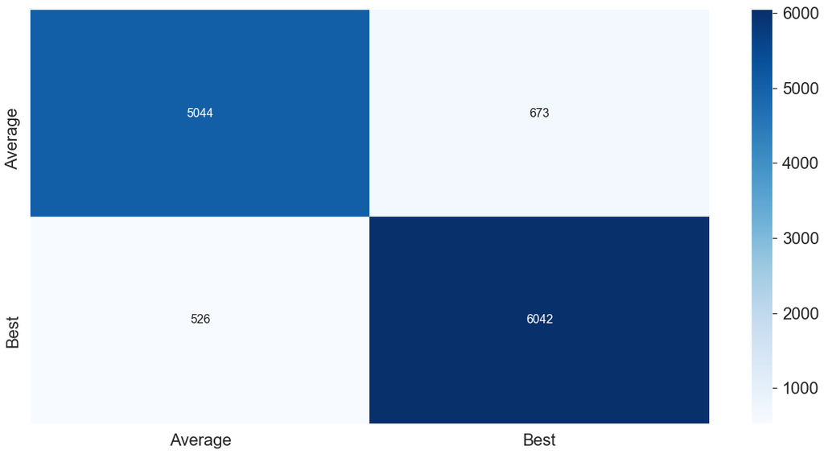

```python
# Generate a confusion matrix using predicted y values against the y from the validation set
array = confusion_matrix(y1_val,y_pred1)
# Create the classes - In this case Average against Best performance
classes = ['Average','Best']
# Create a dataframe from the confusion matrix array and the the classes
df_cm = pd.DataFrame(array, index = [i for i in classes],
                  columns = [i for i in classes])
# Generate the visual matrix using a Seaborn Heat Map
plt.figure(figsize = (20,10))
sn.set(font_scale=2)
sn.set_palette("husl")
sn.heatmap(df_cm, annot=True, annot_kws={"size": 16}, cmap="Blues", fmt='g')
```

**Precision, Recall, and F1 Score**

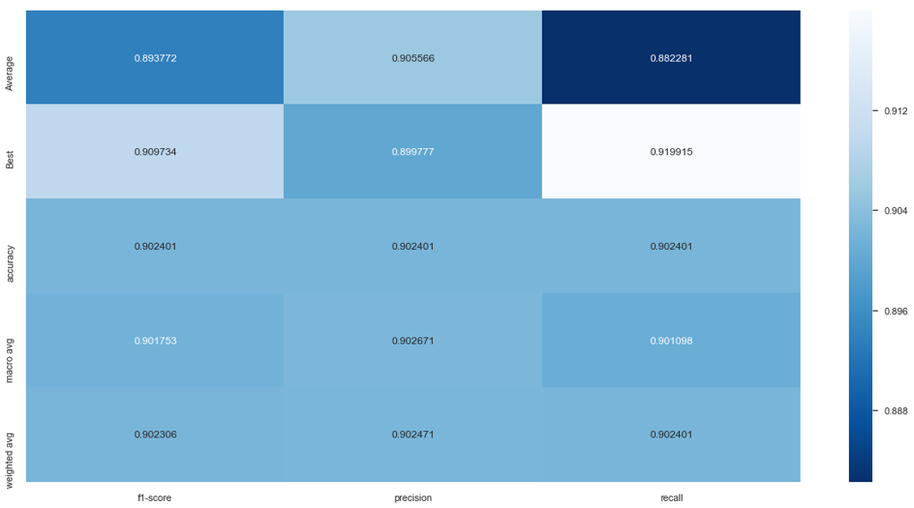

```python
# Create the clasification report
clf_log = classification_report(y1_val, y_pred1, target_names= classes, output_dict=True)
# Create the visualization
plt.figure(figsize = (20,10))
sn.set(font_scale=1)
sn.heatmap(pd.DataFrame(clf_log).iloc[:-1, :].T, annot=True, cmap="Blues_r", fmt='g')
```

**ROC and AUC**

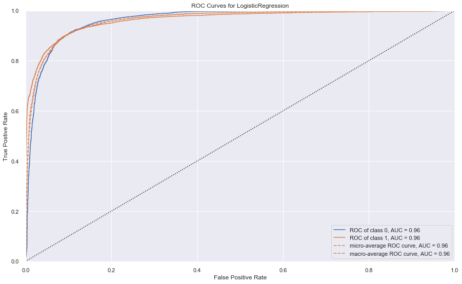

```
ROCAUC(ax=<matplotlib.axes._subplots.AxesSubplot object at 0x123c27278>,
       classes=None, encoder=None, force_model=False, is_fitted='auto',
       macro=True, micro=True, model=None, per_class=True)
```

```python
# ROC and AUC
#Instantiate the visualizer
from yellowbrick.classifier.rocauc import roc_auc

sn.set(font_scale=1)
plt.figure(figsize = (15,9))
roc_auc(model, X1_train, y1_train, X_test=X1_val, y_test=y1_val)
```

## Random Forest Classifier to identify Video Categories

In this round of analysis, I want to see if we can use the tags data to predict which category the video falls under.

```python
# Load NLP related libraries and tools
import nltk
from nltk.stem.lancaster import LancasterStemmer
import os
import datetime
stemmer = LancasterStemmer()
```

```python
# Sub-select the data.
data_fcm = data_r2[['category','tags']]

# Convert the series into a list.
tags_list = data_fcm['tags'].tolist()

# Remove all the pipeline and double quote characters from and store them in a new list.
clean_tags = []
for tag in tags_list:
    clean_tags.append(tag.replace('"', '').replace('|', ' '))

# Turn the category series to a list
cat_list = data_fcm['category'].tolist()

# Empty list
dict_fcm = []

# Create a list of dictionaries.
for i, j in zip(cat_list, clean_tags):
    dict_fcm.append({"cat": i, "txt": j})
```

```python
words = []
classes = []
documents = []
ignore_words = ['?']
# loop through each sentence in our training data
for pattern in dict_fcm:
    # tokenize each word in the sentence
    w = nltk.word_tokenize(pattern['txt'])
    # add to our words list
    words.extend(w)
    # add to documents in our corpus
    documents.append((w, pattern['cat']))
    # add to our classes list
    if pattern['cat'] not in classes:
        classes.append(pattern['cat'])

# stem and lower each word and remove duplicates
words = [stemmer.stem(w.lower()) for w in words if w not in ignore_words]
words = list(set(words))

# remove duplicates
classes = list(set(classes))

# Print the results and show a sample of the words that we gathered.
print (len(documents), "documents")
print (len(classes), "classes", classes)
print (len(words), "unique stemmed words", words[0:1000])
```

```
40949 documents
16 classes ['Entertainment', 'Travel & Events', 'Science & Technology', 'Pets & Animals', 'Howto & Style', 'Nonprofits & Activism', 'People & Blogs', 'News & Politics', 'Shows', 'Film & Animation', 'Gaming', 'Sports', 'Education', 'Comedy', 'Music', 'Autos & Vehicles']
18225 unique stemmed words ['cakebook', 'meant', 'teavan', 'helg', 'c', 'beng', 'stylesheet', 'sufs', 'ep.14', 'netatmo', 'sanjay', 'burrito', 'mrs', 'rockin', 'lovey', 'jabar', 'goaltend', 'samanth', 'aftermath/shady/interscope', 'cracked.com', 'mould', 'lash', 'prism', 'merrelltwin', 'aaliyah', 'v…
```

```python
# create our training data
training = []
output = []
# create an empty array for our output
output_empty = [0] * len(classes)

# training set, bag of words for each sentence
for doc in documents:
    # initialize our bag of words
    bag = []
    # list of tokenized words for the pattern
    pattern_words = doc[0]
    # stem each word
    pattern_words = [stemmer.stem(word.lower()) for word in pattern_words]
    # create our bag of words array
    for w in words:
        bag.append(1) if w in pattern_words else bag.append(0)

    training.append(bag)
    # output is a '0' for each tag and '1' for current tag
    output_row = list(output_empty)
    output_row[classes.index(doc[1])] = 1
    output.append(output_row)

# sample training/output
i = 0
w = documents[i][0]
print ([stemmer.stem(word.lower()) for word in w])
print (training[i])
```

```
['shantel', 'martin']
[0, 0, 0, 0, 0, 0, 0, 0, 0, 0, 0, 0, 0, 0, 0, 0, 0, 0, 0, 0, 0, 0, 0, 0, 0, 0, 0, 0, 0, 0, 0, 0, 0, 0, 0, 0, 0, 0, 0, 0, 0, 0, 0, 0, 0, 0, 0, 0, 0, 0, 0, 0, 0, 0, 0, 0, 0, 0, 0, 0, 0, 0, 0, 0, 0, 0, 0, 0, 0, 0, 0, 0, 0, 0, 0, 0, 0, 0, 0, 0, 0, 0, 0, 0, 0, 0, 0, 0, 0, 0, 0, 0, 0, 0, 0, 0, 0, 0, 0, 0,…
```

```python
# Create labels
from sklearn import preprocessing
le = preprocessing.LabelEncoder()

y = le.fit_transform(cat_list)

# Glimpse of y
y
```

```
array([10,  3,  1, ...,  3,  4,  5])
```

```python
# Divide the data into test and train sets
X_train, X_test, y_train, y_test = train_test_split(training, y, test_size = 0.20)
```

```python
# Feature scaling.
from sklearn.preprocessing import StandardScaler
scaler = StandardScaler()
scaler.fit(X_train)

X_train = scaler.transform(X_train)
X_test = scaler.transform(X_test)
```

**Creating the Model - Random Forest Classifier**

```python
# Import library
from sklearn.ensemble import RandomForestClassifier

# Create the model
clf=RandomForestClassifier(n_estimators=100)

clf.fit(X_train,y_train)
```

```
RandomForestClassifier(bootstrap=True, ccp_alpha=0.0, class_weight=None,
                       criterion='gini', max_depth=None, max_features='auto',
                       max_leaf_nodes=None, max_samples=None,
                       min_impurity_decrease=0.0, min_impurity_split=None,
                       min_samples_leaf=1, min_samples_split=2,
                       min_weight_fraction_leaf=0.0, n_estimators=100,
                       n_jobs=None, oob_score=False, random_state=None,
                       verbose=0, warm_start=False)
```

```python
# Generate the predictions
y_pred=clf.predict(X_test)
```

```python
# Model Accuracy, how often is the classifier correct?
print("Accuracy:",metrics.accuracy_score(y_test, y_pred))
```

```
Accuracy: 0.9666666666666667
```

```python
# Generate the classes - Or in this case, the unique categories.
cat_np = np.array(cat_list)
cat_unique = np.unique(cat_np)
cat_unique = cat_unique.tolist()
cat_unique
```

```
['Autos & Vehicles',
 'Comedy',
 'Education',
 'Entertainment',
 'Film & Animation',
 'Gaming',
 'Howto & Style',
 'Music',
 'News & Politics',
 'Nonprofits & Activism',
 'People & Blogs',
 'Pets & Animals',
 'Science & Technology',
 'Shows',
 'Sports',
 'Travel & Events']
```

**Confusion Matrix**

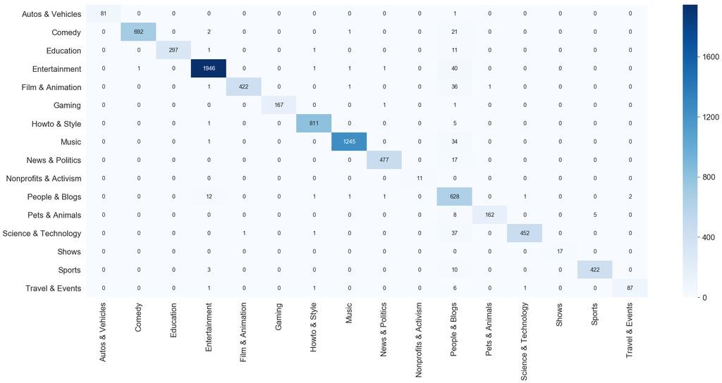

```python
array = confusion_matrix(y_test,y_pred)
df_cm = pd.DataFrame(array, index = [i for i in cat_unique],
                  columns = [i for i in cat_unique])
plt.figure(figsize = (35,15))
sn.set(font_scale=2)
sn.set_palette("husl")
sn.heatmap(df_cm, annot=True, annot_kws={"size": 16}, cmap="Blues", fmt="g")
```

**Classification Report**

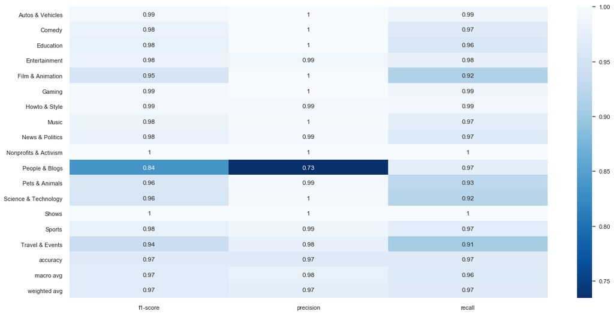

```python
clf_report = classification_report(y_test,y_pred, target_names= cat_unique, output_dict=True)
plt.figure(figsize = (20,10))
sn.set(font_scale=1)
sn.heatmap(pd.DataFrame(clf_report).iloc[:-1, :].T, annot=True, cmap="Blues_r")
```

**ROC and AUC**

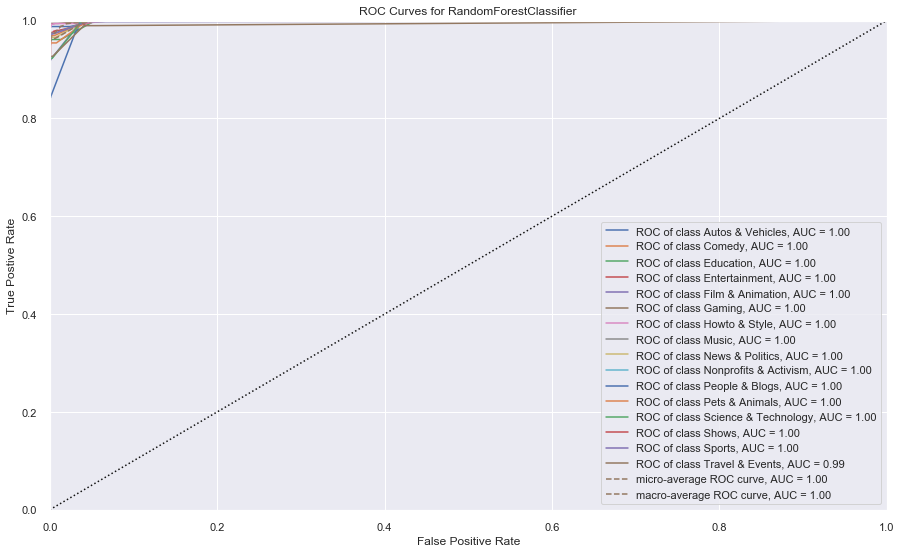

```
ROCAUC(ax=<matplotlib.axes._subplots.AxesSubplot object at 0x1c3fc958d0>,
       classes=['Autos & Vehicles', 'Comedy', 'Education', 'Entertainment',
                'Film & Animation', 'Gaming', 'Howto & Style', 'Music',
                'News & Politics', 'Nonprofits & Activism', 'People & Blogs',
                'Pets & Animals', 'Science & Technology', 'Shows', 'Sports',
                'Travel & Events'],
       encoder=None, force_model=False, is_fitted='auto', macro=True,
       micro=True, model=None, per_class=True)
```

```python
# ROC and AUC
#Instantiate the visualizer

sn.set(font_scale=1)
plt.figure(figsize = (15,9))
roc_auc(clf, X_train, y_train, X_test=X_test, y_test=y_test, classes= cat_unique)
```

Again, another highly accurate model - Perhaps creating a model using Neural Networks or Deep Learning Algorithms and compare the accuracy to see what happens.

```python
from sklearn.neural_network import MLPClassifier
mlp = MLPClassifier(hidden_layer_sizes=(10, 10, 10), max_iter=1000)
mlp.fit(X_train, y_train)
```

```
MLPClassifier(activation='relu', alpha=0.0001, batch_size='auto', beta_1=0.9,
              beta_2=0.999, early_stopping=False, epsilon=1e-08,
              hidden_layer_sizes=(10, 10, 10), learning_rate='constant',
              learning_rate_init=0.001, max_fun=15000, max_iter=1000,
              momentum=0.9, n_iter_no_change=10, nesterovs_momentum=True,
              power_t=0.5, random_state=None, shuffle=True, solver='adam',
              tol=0.0001, validation_fraction=0.1, verbose=False,
              warm_start=False)
```

```python
# Create the predictions
predictions = mlp.predict(X_test)
```

```python
# Model Accuracy, how often is the classifier correct?
print("Accuracy:",metrics.accuracy_score(y_test, predictions))
```

```
Accuracy: 0.9478632478632478
```

**Conclusions**